# Deep Learning for Scandal Prediction

# Environment setup

First we have to set up the environment, by loading the necessary libraries, and defining some helper functions to

- read in the locally stored website source code files
- strip the of unnecessary code and html script
- convert unicode character codes to characters (e.g. *U+00E4* should be displayed as the German letter *ä)*, and
- convert the collection of read-in documents into a Quanteda Corpus object, for easy preprocessing of the text data.

```r
# Load libraries
library("quanteda")
```

```r
library("quanteda.textstats")
library("quanteda.textplots")
library("readtext")
library("stringr")
library("tidyverse")
library("knitr")

# Turn off warnings
knitr::opts_chunk$set(warning = FALSE, message = FALSE)

# Define helper functions to read in raw source code, strip away html code, turn into corpus object
unescape_html <- function(str){
  xml2::xml_text(xml2::read_html(paste0("<x>", str, "</x>")))
}

read_in_reports <- function(server_path) {
  company_reports <- readtext(server_path,
                              docvarsfrom = "filenames",
                              docvarnames = c("company", "year","index"),
                              dvsep = "_",
                              encoding = "UTF-8",
                              verbosity = 0)
  company_reports_clean <- company_reports
  company_reports_clean$text <- gsub(".*<!-- Publication  -->","",company_reports_clean$text)
  company_reports_clean$text <- gsub("<!-- Result Pager Bottom  -->.*","",company_reports_clean$text)
  company_reports_clean$text <- gsub('<table class="std_table".*?</table>', '', company_reports_clean$text)
  company_reports_clean$text <- gsub('</p>', ' Abstzpltzhltr ', company_reports_clean$text)
  company_reports_clean$text <- gsub('<h', ' Abstzpltzhltr -header_start- <', company_reports_clean$text)
  company_reports_clean$text <- gsub('</h', ' -header_end- <', company_reports_clean$text)
  company_reports_clean$text <- gsub('<.*?>', '', company_reports_clean$text)
  company_reports_clean$text <- str_squish(company_reports_clean$text)
  company_reports_clean$text <- gsub('Abstzpltzhltr', '\n', company_reports_clean$text)
  company_reports_clean$text <- sapply(company_reports_clean$text, function(x) unescape_html(x))
  reports_corpus <- corpus(company_reports_clean)
  return(reports_corpus)
}

print('setup complete')
```

```
## [1] "setup complete"
```

# Build and preprocess data set

## Reading and preprocessing the raw text data

To read in and prepare the raw text from the source code files (containing the full corporate report texts) we define the file paths and use the helper functions defined above.

```r
server_path_data1 <- "/Users/pthompson/Dropbox (Box.FU)/NLP/pool_DAX_MDAX_SDAX/DAX/*"
server_path_data2 <- "/Users/pthompson/Dropbox (Box.FU)/NLP/pool_DAX_MDAX_SDAX/MDAX/Pack1/*.txt"
server_path_data3 <- "/Users/pthompson/Dropbox (Box.FU)/NLP/pool_DAX_MDAX_SDAX/MDAX/Pack2/*.txt"
server_path_data4 <- "/Users/pthompson/Dropbox (Box.FU)/NLP/pool_DAX_MDAX_SDAX/SDAX/Pack1/*.txt"
server_path_data5 <- "/Users/pthompson/Dropbox (Box.FU)/NLP/pool_DAX_MDAX_SDAX/SDAX/Pack2/*.txt"

full_reports_corpus <- read_in_reports(server_path_data1)
full_reports_corpus <- full_reports_corpus + read_in_reports(server_path_data2)
full_reports_corpus <- full_reports_corpus + read_in_reports(server_path_data3)
full_reports_corpus <- full_reports_corpus + read_in_reports(server_path_data4)
full_reports_corpus <- full_reports_corpus + read_in_reports(server_path_data5)
```

Because in the data collection some reports were collected twice and stored with slightly different names, we have to drop those duplicate reports. These duplicate reports were identified by searching the folder in which they were stored.

```r
full_reports_corpus <- full_reports_corpus %>%
  corpus_subset(!(company == "Scout24" & index == "SDAX"))

full_reports_corpus <- full_reports_corpus %>%
  corpus_subset(!(company == "Varta" & index == "SDAX"))

full_reports_corpus <- full_reports_corpus %>%
  corpus_subset(!(company == "WincorNixdorf" & index == "MDAX"))

full_reports_corpus <- full_reports_corpus %>%
  corpus_subset(!(company == "capital-stage-ag"))

full_reports_corpus <- full_reports_corpus %>%
  corpus_subset(!(company == "mpc-münchmeyer-petersen&co-gmbh"))
```

There are also some reports stored under the wrong names (the confusion arose due to name changes of otherwise unchanged companies). These names have to be corrected.

```r
full_reports_corpus$company[full_reports_corpus$company == "balda-ag"] <- "clere-ag"
full_reports_corpus$company[full_reports_corpus$company == "cat-oil"] <- "petro-welt-technologies-ag"
full_reports_corpus$company[full_reports_corpus$company == "constantin-medien"] <- "sport1-medien-ag"
full_reports_corpus$company[full_reports_corpus$company == "S&T"] <- "kontron-s&t-ag"
```

Later inspection also revealed that a handful of reports were overlooked during data collection. These missing reports were gathered and stored in a folder (“missing”), and now have to be preprocessed and added to corpus.

```r
server_path_dataM <- "/Users/pthompson/Dropbox (Box.FU)/NLP/pool_DAX_MDAX_SDAX/missing/*"

full_reports_corpus <- full_reports_corpus + read_in_reports(server_path_dataM)
```

## Extraction of paragraphs that report on ESG matters

Since the full corporate reports are extremely long, and contain a lot of reporting on matters of strategy, finances, etc. with no direct connection to ESG topics, we want to filter to only retain paragraphs that mention ESG topics.

To this end, we first have to define a helper function segment_and_extract(corpus,keywords,output) that, given a set of keywords (for ESG topics) and a desired output style, strip the full reports in the full_reports_corpus corpus object to only paragraphs featuring the keywords.

Parameters:

- **corpus**: A Quanteda corpus object that contains the full reports to be cut down
- **keywords**: A list of strings, which are to be searched in the paragraphs. When there’s a match to one or more keywords within a paragraph, that paragraph is retained.
- **output**: A string indicating the desired output format. Either **“corpus_segmented”**, which returns a version of the corpus object with texts broken down into paragraphs, without filtering on keywords, or **“window_segmented”**, which returns a corpus object of only those paragraphs that contain one or more keywords, or **“window_merged”**, which returns a corpus object of the paragraphs that contain one or more keywords, merged back together into a single cell for each report.

```r
# following function can either extract the full, but segtmented corpus,
# or only segments with ESG keywords,
# or segments with ESG keywords merged together (i.e. one cell per company-year)

segment_and_extract <- function(corpus,keywords,output) {
  reports_corpus_seg <- corpus_segment(corpus, pattern = '\n', valuetype = "glob",
                                       pattern_position = "before", use_docvars = TRUE)
  reports_corpus_seg$ntoken <- ntoken(reports_corpus_seg)
  reports_corpus_seg <- corpus_subset(reports_corpus_seg, ntoken > 0)
  reports_corpus_seg$filter <- str_detect(reports_corpus_seg,
                                          regex(paste(keywords, collapse = "|"),ignore_case = TRUE))
  if (output == "corpus_segmented") {
    return(reports_corpus_seg)
  } else {
    reports_corpus_seg_trim <- corpus_subset(reports_corpus_seg, filter == TRUE)
    reports_corpus_seg$firmyear <- paste0(reports_corpus_seg$company,reports_corpus_seg$year)
    reports_corpus_seg_trim$firmyear <- paste0(reports_corpus_seg_trim$company,reports_corpus_seg_trim$year)
    if (output == "window_segmented") {
      return(reports_corpus_seg_trim)
    } else {
      reports_corpus_window <- corpus_group(reports_corpus_seg_trim, groups = firmyear,concatenator = " ")
      if (output == "window_merged") {
        return(reports_corpus_window)
      } else stop("invalid output setting")
    }
  }
}
```

Next, we have to define a list of keywords with which we want to filter the full report texts. Here, these are broken down into keywords related to the social and environmental dimensions of ESG, and the governance dimension of ESG (since the governance (G) dimension is economically motivated, one may choose to only look at the social responsibility-motivated E and S dimensions).

```r
# keywords to identify paragraphs featuring social and ecological reporting
keywords_csr <- c("Diversität","Diversity","Frauen","Geschlecht","weiblich",
                  "Teilhabe","Gleichberechtigung","Gleichstellung","nachhaltig",
                  "Sustainability","Umwelt","klima","Emission","emission","ökologisch",
                  "sustainab", "Abfall","Wasserverbrauch","Ressource","Rohstoff",
                  "sozial","Menschenrechte","Stakeholder", "Charta der Vielfalt",
                  "Global Compact","SDG","Mitarbeiter",
                  "Compliance","verantwortungsvoll","verantwortungsbewusst")

# keywords zur Identifikation von Governance-relevanten Textstellen
keywords_governance <- c("Unternehmensführung","Führungsebene","Leitungsebene","Führungskr","Führungsperson",
                         "Führungssystem","Governance","Kodex","Aufsichtsr","board",
                         "Vorstand","Vorständ","Ausschuss","Komitee","comittee","Committee")

keywords <- c(keywords_csr,keywords_governance)
```

Now, we can run the segment_and_extract() helper function with the keywords we defined. Afterwards, we just need to drop a handful reports that were filed for broken-up fiscal years, and whose content can’t be clearly linked with the corresponding scandals data points.

Note: Since we want to use recurrent neural networks when training a classification model, the input text sequences cannot be too long. There we choose the “window_segmented” output style, aiming to train the neural network on individual paragraphs taken from the reports.

```r
reports_corpus_seg_trim <- segment_and_extract(full_reports_corpus,keywords = keywords,output = "window_segmented")

reports_corpus_seg_trim <- convert(reports_corpus_seg_trim, to = "data.frame")

# drop broken-up years
reports_corpus_seg_trim <- reports_corpus_seg_trim %>%
  filter(!(year %in% c("2013a","2013b","2016a","2016b","2017a","2017b")))
```

## Reading and preprocessing the target variable

First, we have to read in the Excel-Spreadsheet containing the data about companies’ ‘controversy score’, i.e. a measure of whether they are involved in ongoing media scandals over ESG topics. To read in the spreadsheet, we do:

```r
library("readxl")
excel_path <- "/Users/pthompson/Dropbox (Box.FU)/TTT/R data/Eikon_data.xlsx"

eikon_data <- read_excel(excel_path, sheet = "Collection list", col_names = TRUE,
                         progress = TRUE) %>%
  as.data.frame() %>%
  select(company,`company name`,datastream_id,year,`ESG Controversies Score`)
```

```
##
-
/


/


-
```

As part of cleaning the scandals data, we have to drop duplicate rows, which can be identified by their identical combination of company and year:

```r
eikon_data$firmyear <- paste0(eikon_data$datastream_id,eikon_data$year)
eikon_data <- distinct(eikon_data, firmyear,.keep_all = TRUE)
```

To turn the variable ‘ESG Controversies Score’ into our target, we have to first recode it to a binary indicator of whether or not a company is in a given year involved in a scandal. The ‘ESG Controversies Score’ x is…

- x = 100 if a company is scandal-free in a given year,
- 0 ≤ x < 100 if a company is involved in a scandal in a given year (with lower values indicating greater severity)
- x = ‘NA’ if a company was not covered by Refinitv ESG analysts.

Accordingly, we mutate the ‘ESG Controversies Score’ into a new variable ‘controversy’, that is FALSE when a company was scandal-free, TRUE when a company was involved in a scandal, and NA if a company was not covered and the data is thus missing.

```r
eikon_data$controversy <- NA
eikon_data$controversy[!(eikon_data$`ESG Controversies Score` == "NA")] <- TRUE
eikon_data$controversy[eikon_data$`ESG Controversies Score` == "100"] <- FALSE

# Optional: retain controversy_score as optional target for regression modeling
eikon_data <- eikon_data %>%
  rename(controversy_score = `ESG Controversies Score`)
eikon_data <- eikon_data %>%
  mutate(controversy_score = na_if(controversy_score, "NA"))
eikon_data$controversy_score <- as.numeric(eikon_data$controversy_score)
```

Secondly, as our aim is the prediction of future scandals from companies’ current reporting, we have to generate a variable that indicates whether a company experienced a scandal in the two following years:

```r
contro_t1 <- eikon_data %>%
  select(datastream_id,year,controversy_score,controversy)
contro_t1 <- contro_t1 %>%
  mutate(year = year - 1)
contro_t1 <- contro_t1 %>%
  rename(controversy_score_t1 = controversy_score,
         controversy_t1 = controversy)
contro_t2 <- eikon_data %>%
  select(datastream_id,year,controversy_score,controversy)
contro_t2 <- contro_t2 %>%
  mutate(year = year - 2)
contro_t2 <- contro_t2 %>%
  rename(controversy_score_t2 = controversy_score,
         controversy_t2 = controversy)

eikon_data <- left_join(eikon_data,contro_t1,by = c("datastream_id", "year"))
eikon_data <- left_join(eikon_data,contro_t2,by = c("datastream_id", "year"))
eikon_data <- eikon_data %>%
  mutate(future_controversy = (controversy_t1 | controversy_t2))

rm(contro_t1,contro_t2)
```

We end up with our target variable *future_controversy*, which is TRUE if a company experienced a scandal in either of the following two years, and FALSE if it remained scandal-free over the same period.

## Building together the dataset for training and evaluation

Now that we have preprocessed a) the text data from the corporate reports, and b) the scandals data from Refinitiv, we can merge both tables together to create the complete data set for model training and evaluation. We do this with the help of another table, ‘All_IDs’, which connects the keys from the other tables.

```r
excel_path <- "/Users/pthompson/Dropbox (Box.FU)/TTT/R data/all_IDs.xlsx"

# need to merge in keys (IDs) to merge together text and scandals dataframes
all_IDs <- read_excel(excel_path, sheet = "connectedIDs", col_names = TRUE,
                      progress = TRUE) %>%
  as.data.frame()
```

```
##
-
/


/


-
```

```r
reports_corpus_seg_trim$year <- as.numeric(reports_corpus_seg_trim$year)

# we first join the keys into reports_corpus_seg_trim
reports_corpus_seg_trim <- reports_corpus_seg_trim %>%
  left_join(all_IDs, by = c("company"))

# ...and then the scandals data from eikon_data.
reports_corpus_seg_trim <- reports_corpus_seg_trim %>%
  left_join(eikon_data, by = c("datastream_id", "year"))

TTT_analysis_corpus <- reports_corpus_seg_trim

head(TTT_analysis_corpus)
```

|  | doc_id | text | company.x | year | index | pattern | ntoken | filter | firmyear.x | BoardName | BoardID | ISIN | company name.x | datastream_id | company.y | company name.y | controversy_score | firmyear.y | controversy | controversy_score_t1 | controversy_t1 | controversy_score_t2 | controversy_t2 | future_controversy |
| --- | --- | --- | --- | --- | --- | --- | --- | --- | --- | --- | --- | --- | --- | --- | --- | --- | --- | --- | --- | --- | --- | --- | --- | --- |
| 1 | adidas_2009_DAX.txt.7 | -header_start- Reorganisation des Konzerns schafft solide Grundlage für Wachstum -header_end- Im Jahr 2009 entschied sich der adidas Konzern, anstelle der bisherigen vertikal integrierten Markenstrukt… | adidas | 2009 | DAX | \n | 133 | TRUE | adidas2009 | ADIDAS AG (Adidas-Salomon prior to 06/2006) | 792 | DE000A1EWWW0 | ADIDAS | D:ADS | adidas | ADIDAS | 62.5 | D:ADS2009 | TRUE | 30 | TRUE | 10 | TRUE | TRUE |
| 2 | adidas_2009_DAX.txt.11 | ― Aufteilung der Verantwortlichkeiten zwischen dem Management von Global Brands und Global Sales auf Vorstandsebene. Herbert Hainer, Vorstandsvorsitzender des adidas Konzerns, übernahm zusätzlich die … | adidas | 2009 | DAX | \n | 50 | TRUE | adidas2009 | ADIDAS AG (Adidas-Salomon prior to 06/2006) | 792 | DE000A1EWWW0 | ADIDAS | D:ADS | adidas | ADIDAS | 62.5 | D:ADS2009 | TRUE | 30 | TRUE | 10 | TRUE | TRUE |
| 3 | adidas_2009_DAX.txt.26 | Unser Augenmerk liegt zudem auf der Erreichung bestmöglicher Sozialund Umweltstandards. Wir fördern sozial und ökologisch verantwortungsvolles Handeln, weil wir wissen, dass dies für unseren Konzern e… | adidas | 2009 | DAX | \n | 43 | TRUE | adidas2009 | ADIDAS AG (Adidas-Salomon prior to 06/2006) | 792 | DE000A1EWWW0 | ADIDAS | D:ADS | adidas | ADIDAS | 62.5 | D:ADS2009 | TRUE | 30 | TRUE | 10 | TRUE | TRUE |
| 4 | adidas_2009_DAX.txt.28 | -header_start- Schaffen von Shareholder Value -header_end- Nachhaltiges Wachstum bei Umsatz und Betriebsergebnis ist entscheidend für unseren Konzernerfolg. Im Mittelpunkt unseres unternehmerischen En… | adidas | 2009 | DAX | \n | 111 | TRUE | adidas2009 | ADIDAS AG (Adidas-Salomon prior to 06/2006) | 792 | DE000A1EWWW0 | ADIDAS | D:ADS | adidas | ADIDAS | 62.5 | D:ADS2009 | TRUE | 30 | TRUE | 10 | TRUE | TRUE |
| 5 | adidas_2009_DAX.txt.61 | -header_start- Einzelhandel: Entwicklung zu einem der führenden Einzelhändler der Welt -header_end- Unsere strategische Vision für das Einzelhandelssegment besteht darin, durch gesundes, nachhaltiges … | adidas | 2009 | DAX | \n | 127 | TRUE | adidas2009 | ADIDAS AG (Adidas-Salomon prior to 06/2006) | 792 | DE000A1EWWW0 | ADIDAS | D:ADS | adidas | ADIDAS | 62.5 | D:ADS2009 | TRUE | 30 | TRUE | 10 | TRUE | TRUE |
| 6 | adidas_2009_DAX.txt.69 | -header_start- Menschen ("People") -header_end- Der Konsument und unsere Einzelhandelsmitarbeiter sind die primären Bezugspunkte für das Geschäftsmodell unseres Einzelhandelssegments. Wir sind fortlau… | adidas | 2009 | DAX | \n | 110 | TRUE | adidas2009 | ADIDAS AG (Adidas-Salomon prior to 06/2006) | 792 | DE000A1EWWW0 | ADIDAS | D:ADS | adidas | ADIDAS | 62.5 | D:ADS2009 | TRUE | 30 | TRUE | 10 | TRUE | TRUE |

# Deep Learning with Keras

## Set up Keras

In order to use Keras in R, we need to a) load the necessary libraries, and b) ‘reticulate’, i.e. tie a version of Python into the R session.

```r
library(caret)
library(keras)
library(tensorflow)
library(reticulate)
use_condaenv(condaenv = "TensorFlow", conda = "auto", required = NULL)
set_random_seed(32)
```

## Build feature tensor

We first tidy up our data a bit, by dropping missing values on the target, dropping text sequences shorter than 10 words (likely headings or single-sentence paragraphs), and keeping only columns we will use in model training.

```r
raw_data <- TTT_analysis_corpus %>%
  filter(!(is.na(future_controversy))) %>%
  filter(ntoken > 10) %>%
  select(doc_id,company.x,year,text,future_controversy,ntoken)
```

In order to be able to validate the neural networks that we train, we will need to perform a train-test split on the data. We use the most recent 3 years as the validation data, because our aim is to predict future controversies based on past data, and because we don’t want to risk data leakage (by training a model on data from all periods including the latest, and then using it to ‘predict’ scandals in earlier periods). The actual train-test split is performed a bit further below, but we first have to shuffle the data in the train and test sets separately, to avoid order effects on the training. We implement this like:

```r
raw_train <- raw_data %>%
  filter(year < 2019)
raw_train <- raw_train[sample(1:nrow(raw_train)), ]

end_of_train <- nrow(raw_train)
#to index the training set: texts[1:end_of_train]

raw_test <- raw_data %>%
  filter(year>2018)
raw_test <- raw_test[sample(1:nrow(raw_test)), ]

end_of_test <- nrow(raw_train) + nrow(raw_test)
```

## Tokenization

When tokenizing, we have to determine the appropriate vocabulary size. To this end, we should figure out the number of unique words found in our text corpus. Below code implements different methods of trimming the corpus.

```r
count_corpus <- corpus(TTT_analysis_corpus$text)
count_toks <- tokens(
  count_corpus,
  remove_punct = TRUE,
  remove_symbols = FALSE,
  remove_numbers = FALSE,
  remove_url = FALSE,
  remove_separators = TRUE,
  split_hyphens = FALSE,
  split_tags = FALSE,
  include_docvars = FALSE,
  padding = FALSE,
  verbose = quanteda_options("verbose"))
count_dfmat <- dfm(count_toks)
print(paste0('max word count for full corpus: ',nfeat(count_dfmat)))
```

```
## [1] "max word count for full corpus: 352048"
```

```r
count_corpus2 <- TTT_analysis_corpus %>%
  filter(!(is.na(future_controversy)))
count_corpus2 <- corpus(count_corpus2$text)
count_toks2 <- tokens(
  count_corpus2,
  remove_punct = TRUE,
  remove_symbols = FALSE,
  remove_numbers = FALSE,
  remove_url = FALSE,
  remove_separators = TRUE,
  split_hyphens = FALSE,
  split_tags = FALSE,
  include_docvars = FALSE,
  padding = FALSE,
  verbose = quanteda_options("verbose"))
count_dfmat2 <- dfm(count_toks2)
print(paste0('max word count for corpus with nonmissing controversy data',
             nfeat(count_dfmat2)))
```

```
## [1] "max word count for corpus with nonmissing controversy data255157"
```

```r
count_dfmat3 <- dfm_trim(count_dfmat2, min_docfreq = 3)
print(paste0('max word count for corpus with nonmissing controversy data after dropping highly infrequent terms (min_docfreq = 3)',nfeat(count_dfmat3)))
```

```
## [1] "max word count for corpus with nonmissing controversy data after dropping highly infrequent terms (min_docfreq = 3)117979"
```

```r
count_dfmat4 <- dfm_trim(count_dfmat2, min_docfreq = 10)
print(paste0('max word count for corpus with nonmissing controversy data after dropping infrequent terms (min_docfreq = 3)',nfeat(count_dfmat4)))
```

```
## [1] "max word count for corpus with nonmissing controversy data after dropping infrequent terms (min_docfreq = 3)53080"
```

Next, we can tokenize the text, and turn it into sequences. While doing so, we have to decide how large our vocabulary should be (max_words) and to which maximum length we want to trim the sequences (maxlen).

```r
maxlen <- 300 # 99% of text sequences are smaller than this.
max_words <- 50000 #this is close to the total vocabulary size when dropping infrequent words (appearing less than 10 times in the corpus), and practicable, as a larger vocabulary could easily overload our computational resources.

texts <- c(raw_train$text,raw_test$text)
tokenizer <- text_tokenizer(num_words = max_words) %>%
  fit_text_tokenizer(texts)
sequences <- texts_to_sequences(tokenizer, texts)
word_index = tokenizer$word_index
cat(length(word_index), "unique tokens found.\n")
```

```
## 186325 unique tokens found.
```

```r
data <- pad_sequences(sequences, maxlen = maxlen)
```

With some final reformating, and by re-instating the train-test-split on the now tokenized data, we arrive at the 2D feature tensor (containing the tokenized text sequences) necessary as input to the neural network, and a target array containing the future_controversy label.

```r
labels <- as.numeric(c(raw_train$future_controversy,raw_test$future_controversy))
labels <- as.array(labels)

cat('Shape of the feature tensor:', dim(data), "\n")
```

```
## Shape of the feature tensor: 325943 300
```

```r
cat('Shape of the label tensor:', dim(labels), "\n")
```

```
## Shape of the label tensor: 325943
```

```r
indices <- 1:nrow(data)
training_indices <- indices[1:end_of_train]
validation_indices <- indices[(end_of_train + 1):
                                end_of_test]
x_train <- data[training_indices,]
y_train <- labels[training_indices]
x_val <- data[validation_indices,]
y_val <- labels[validation_indices]

cat('Shape of x_train:', dim(x_train), "\n")
```

```
## Shape of x_train: 257561 300
```

```r
cat('Shape of y_train:', dim(y_train), "\n")
```

```
## Shape of y_train: 257561
```

```r
cat('Shape of x_val:', dim(x_val), "\n")
```

```
## Shape of x_val: 68382 300
```

```r
cat('Shape of y_val:', dim(y_val), "\n")
```

```
## Shape of y_val: 68382
```

## Fitting and Comparing Models

### Naive Prediction: Most frequent class

```r
y_naive <- as.array(rep(0,length(y_val)))

confusion_mat <- confusionMatrix(factor(y_naive),factor(y_val))
print(confusion_mat)
```

```
## Confusion Matrix and Statistics
##
##           Reference
## Prediction     0     1
##          0 32656 35726
##          1     0     0
##
##                Accuracy : 0.4776
##                  95% CI : (0.4738, 0.4813)
##     No Information Rate : 0.5224
##     P-Value [Acc > NIR] : 1
##
##                   Kappa : 0
##
##  Mcnemar's Test P-Value : <2e-16
##
##             Sensitivity : 1.0000
##             Specificity : 0.0000
##          Pos Pred Value : 0.4776
##          Neg Pred Value :    NaN
##              Prevalence : 0.4776
##          Detection Rate : 0.4776
##    Detection Prevalence : 1.0000
##       Balanced Accuracy : 0.5000
##
##        'Positive' Class : 0
##
```

The naive prediction achieves an accuracy of about 50%.

### Word embeddings

One of the simplest deep learning models we can build is one that utilizes word embeddings to encode patterns among the words in the text (e.g. semantic similarity), and then feeds these vectorized representations to some dense network layers that learn how these relate to the target (scandal occurrence).

```r
#simple embeddings + multilayer perceptron
set_random_seed(32)

model1 <- keras_model_sequential() %>%
  layer_embedding(input_dim = max_words, output_dim = 32,
                  input_length = maxlen) %>%
  layer_flatten() %>%
  layer_dense(units = 16, activation = "relu") %>%
  layer_dense(units = 16, activation = "relu") %>%
  layer_dense(units = 1, activation = "sigmoid")


model1 %>% compile(
  #optimizer=optimizer_adam(),
  optimizer = "adam",
  loss = "binary_crossentropy",
  metrics = c("acc")
  )

summary(model1)
```

```
## Model: "sequential"
## _________________________________________________________________________________________________________________________
##  Layer (type)                                         Output Shape                                    Param #
## =========================================================================================================================
##  embedding (Embedding)                                (None, 300, 32)                                 1600000
##  flatten (Flatten)                                    (None, 9600)                                    0
##  dense_2 (Dense)                                      (None, 16)                                      153616
##  dense_1 (Dense)                                      (None, 16)                                      272
##  dense (Dense)                                        (None, 1)                                       17
## =========================================================================================================================
## Total params: 1,753,905
## Trainable params: 1,753,905
## Non-trainable params: 0
## _________________________________________________________________________________________________________________________
```

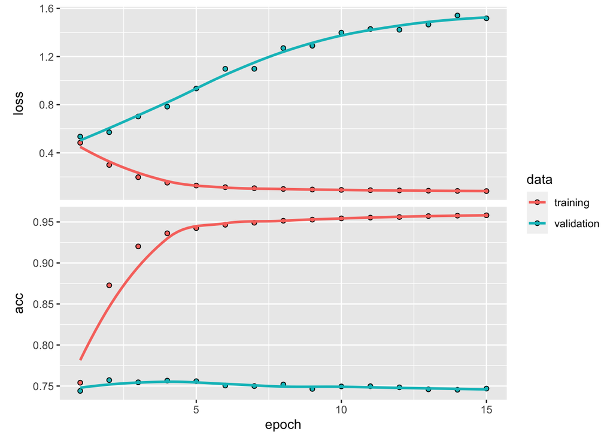

```r
history <- model1 %>% fit(
  x_train, y_train,
  validation_data = list(x_val, y_val),
  epochs = 15, # 15 is probably enough
  batch_size = 128,
  verbose = 0
)

plot(history)
```

```r
print(paste0("peak accuracy of the model: ",max(history$metrics$val_acc)))
```

```
## [1] "peak accuracy of the model: 0.75715833902359"
```

```r
rm(model1)
set_random_seed(32)

model1 <- keras_model_sequential() %>%
  layer_embedding(input_dim = max_words, output_dim = 32,
                  input_length = maxlen) %>%
  layer_flatten() %>%
  layer_dense(units = 16, activation = "relu") %>%
  layer_dense(units = 16, activation = "relu") %>%
  layer_dense(units = 1, activation = "sigmoid")

model1 %>% compile(
  optimizer = "adam",
  loss = "binary_crossentropy",
  metrics = c("acc")
  )

model1 %>% fit(
  x_train, y_train,
  validation_data = list(x_val, y_val),
  epochs = 4,
  batch_size = 128,
  verbose = 0
)
```

### Recurrent Neural Network (RNN)

The last model, a simple architecture using word embeddings and dense layers, already performed quite well. However, the history plot suggests that the model learns few new generalizable features (i.e. that improve validation performance) after the third epoch. We can try to improve the learning behavior by expanding the hypothesis space that the network can cover. One way to do this is by using recurrent neural network layers, which don’t just analyze individually words, but also consider their sequence. They’re thus able to “understand” meaning spread across multiple words, sentences, etc.

```r
set_random_seed(32)

model2 <- keras_model_sequential() %>%
  layer_embedding(input_dim = max_words, output_dim = 32,
                  input_length = maxlen) %>%
  layer_simple_rnn(units = 32) %>%
  layer_dense(units = 1, activation = "sigmoid")


model2 %>% compile(
  optimizer = "adam",
  loss = "binary_crossentropy",
  metrics = c("acc")
  )

summary(model2)
```

```
## Model: "sequential_2"
## _________________________________________________________________________________________________________________________
##  Layer (type)                                         Output Shape                                    Param #
## =========================================================================================================================
##  embedding_2 (Embedding)                              (None, 300, 32)                                 1600000
##  simple_rnn (SimpleRNN)                               (None, 32)                                      2080
##  dense_6 (Dense)                                      (None, 1)                                       33
## =========================================================================================================================
## Total params: 1,602,113
## Trainable params: 1,602,113
## Non-trainable params: 0
## _________________________________________________________________________________________________________________________
```

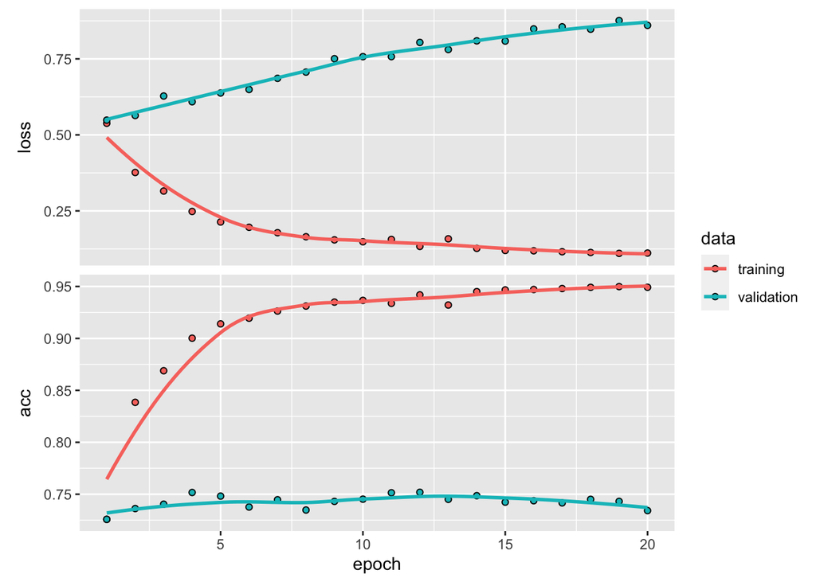

```r
history <- model2 %>% fit(
  x_train, y_train,
  validation_data = list(x_val, y_val),
  epochs = 20,
  batch_size = 128,
  verbose = 0
  )

plot(history)
```

```r
print(paste0("peak accuracy of the model: ",max(history$metrics$val_acc)))
```

```
## [1] "peak accuracy of the model: 0.751879155635834"
```

```r
rm(model2)
set_random_seed(32)

model2 <- keras_model_sequential() %>%
  layer_embedding(input_dim = max_words, output_dim = 32,
                  input_length = maxlen) %>%
  layer_simple_rnn(units = 32) %>%
  layer_dense(units = 1, activation = "sigmoid")

model2 %>% compile(
  optimizer = "adam",
  loss = "binary_crossentropy",
  metrics = c("acc")
  )

model2 %>% fit(
  x_train, y_train,
  validation_data = list(x_val, y_val),
  epochs = 12,
  batch_size = 128,
  verbose = 0
)
```

### LSTM Recurrent Layers

A more sophisticated approach to recurrent neural network layers are LSTM (Long-Short-Term-Memory) layers, which can dynamically update the model state to differently weigh information at greater and smaller distance from the current step (word) in the text sequence.

```r
set_random_seed(32)

model3 <- keras_model_sequential() %>%
  layer_embedding(input_dim = max_words, output_dim = 32,
                  input_length = maxlen) %>%
  layer_lstm(units = 32) %>%
  layer_dense(units = 1, activation = "sigmoid")


model3 %>% compile(
  optimizer = "adam",
  loss = "binary_crossentropy",
  metrics = c("acc")
  )

summary(model3)
```

```
## Model: "sequential_4"
## _________________________________________________________________________________________________________________________
##  Layer (type)                                         Output Shape                                    Param #
## =========================================================================================================================
##  embedding_4 (Embedding)                              (None, 300, 32)                                 1600000
##  lstm (LSTM)                                          (None, 32)                                      8320
##  dense_8 (Dense)                                      (None, 1)                                       33
## =========================================================================================================================
## Total params: 1,608,353
## Trainable params: 1,608,353
## Non-trainable params: 0
## _________________________________________________________________________________________________________________________
```

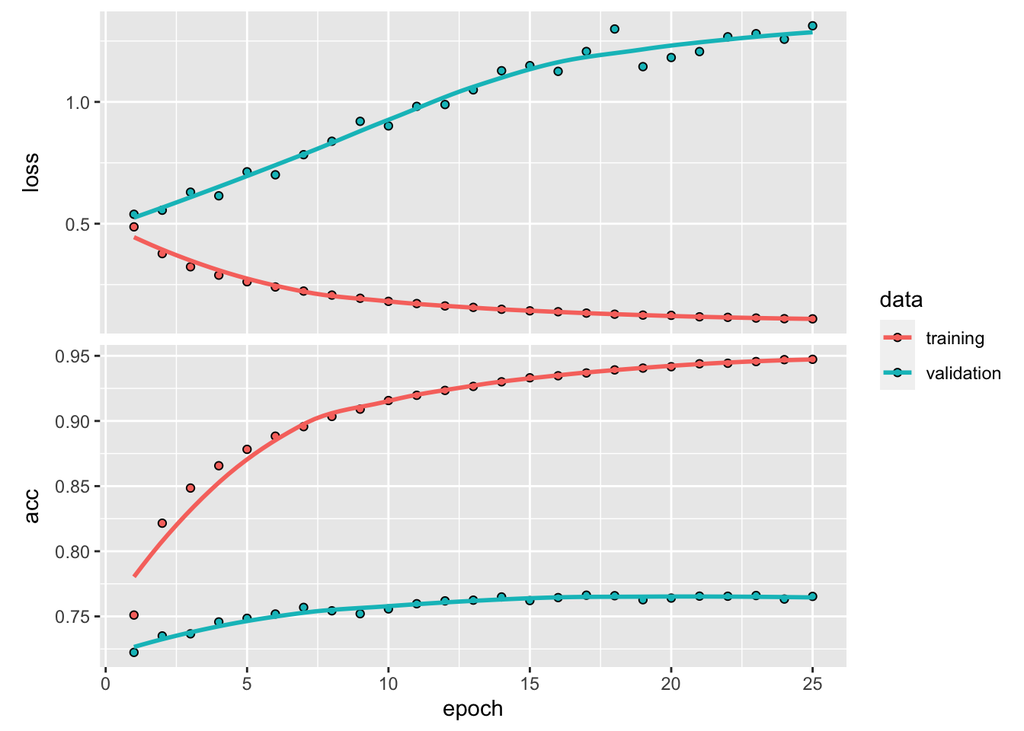

```r
history <- model3 %>% fit(
  x_train, y_train,
  validation_data = list(x_val, y_val),
  epochs = 25,
  batch_size = 128,
  verbose = 0
  )

plot(history)
```

```r
print(paste0("peak accuracy of the model: ",max(history$metrics$val_acc)))
```

```
## [1] "peak accuracy of the model: 0.766268908977509"
```

We can further tweak the learning potential of the LSTM-based model by making the LSTM layer bi-directional. This way, the recurrent layer can parse information (e.g. relationships between words in a statement) both forwards and backwards, rather than only forwards.

```r
set_random_seed(32)

model3b <- keras_model_sequential() %>%
  layer_embedding(input_dim = max_words, output_dim = 32,
                  input_length = maxlen) %>%
  bidirectional(layer_lstm(units = 32)) %>%
  layer_dense(units = 1, activation = "sigmoid")


model3b %>% compile(
  optimizer = "adam",
  loss = "binary_crossentropy",
  metrics = c("acc")
  )

summary(model3b)
```

```
## Model: "sequential_5"
## _________________________________________________________________________________________________________________________
##  Layer (type)                                         Output Shape                                    Param #
## =========================================================================================================================
##  embedding_5 (Embedding)                              (None, 300, 32)                                 1600000
##  bidirectional (Bidirectional)                        (None, 64)                                      16640
##  dense_9 (Dense)                                      (None, 1)                                       65
## =========================================================================================================================
## Total params: 1,616,705
## Trainable params: 1,616,705
## Non-trainable params: 0
## _________________________________________________________________________________________________________________________
```

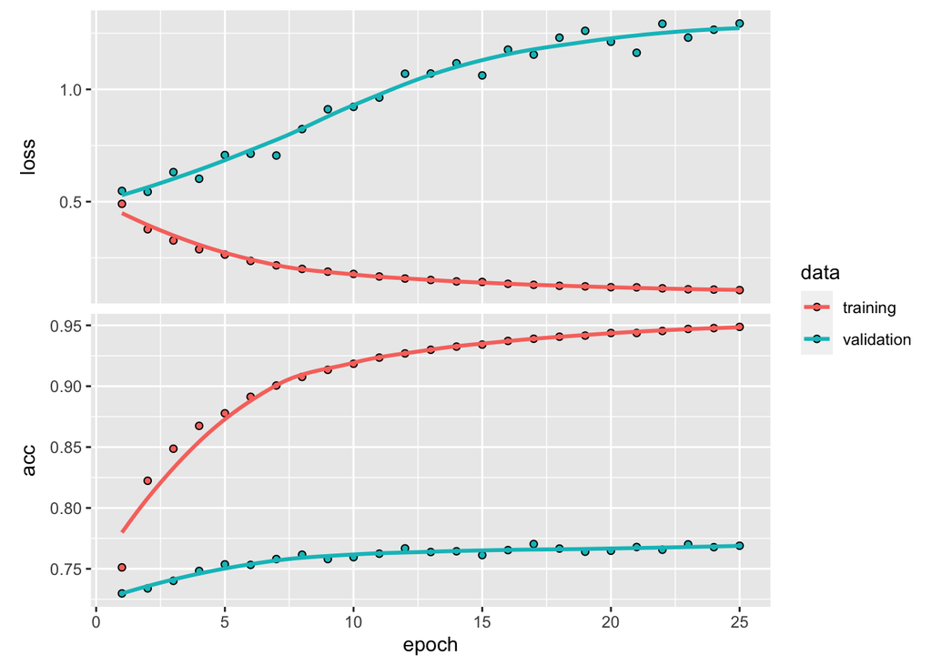

```r
history <- model3b %>% fit(
  x_train, y_train,
  validation_data = list(x_val, y_val),
  epochs = 25,
  batch_size = 128,
  verbose = 0
  )

plot(history)
```

```r
print(paste0("peak accuracy of the model: ",max(history$metrics$val_acc)))
```

```
## [1] "peak accuracy of the model: 0.770348906517029"
```

### 1-Dimensional Convolutional Neural Network - checked

Another way to process sequential data (like text) is using 1-dimensional convolutional network layers, which are also able to learn multi-word/sentence patterns.

```r
set_random_seed(32)

model4 <- keras_model_sequential() %>%
  layer_embedding(input_dim = max_words, output_dim = 32,
                  input_length = maxlen) %>%
  layer_conv_1d(filters = 32, kernel_size = 7,
                activation = "relu") %>%
  layer_max_pooling_1d(pool_size = 5) %>%
  layer_conv_1d(filters = 32, kernel_size = 7,
                activation = "relu") %>%
  layer_global_max_pooling_1d() %>%
  layer_dense(units = 1, activation = "sigmoid")


model4 %>% compile(
  optimizer = "adam",
  loss = "binary_crossentropy",
  metrics = c("acc")
  )

summary(model4)
```

```
## Model: "sequential_6"
## _________________________________________________________________________________________________________________________
##  Layer (type)                                         Output Shape                                    Param #
## =========================================================================================================================
##  embedding_6 (Embedding)                              (None, 300, 32)                                 1600000
##  conv1d_1 (Conv1D)                                    (None, 294, 32)                                 7200
##  max_pooling1d (MaxPooling1D)                         (None, 58, 32)                                  0
##  conv1d (Conv1D)                                      (None, 52, 32)                                  7200
##  global_max_pooling1d (GlobalMaxPooling1D)            (None, 32)                                      0
##  dense_10 (Dense)                                     (None, 1)                                       33
## =========================================================================================================================
## Total params: 1,614,433
## Trainable params: 1,614,433
## Non-trainable params: 0
## _________________________________________________________________________________________________________________________
```

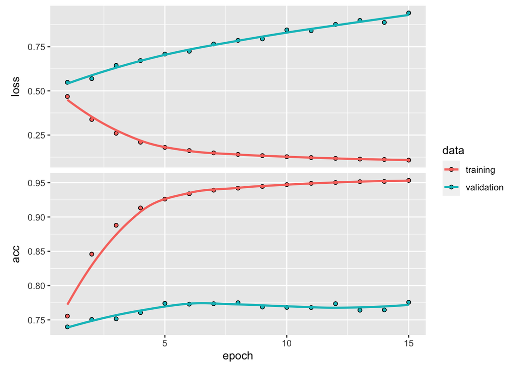

```r
history <- model4 %>% fit(
  x_train, y_train,
  validation_data = list(x_val, y_val),
  epochs = 15,
  batch_size = 128,
  verbose = 0
  )

plot(history)
```

```r
print(paste0("peak accuracy of the model: ",max(history$metrics$val_acc)))
```

```
## [1] "peak accuracy of the model: 0.775715827941895"
```

```r
rm(model4)
set_random_seed(32)

model4 <- keras_model_sequential() %>%
  layer_embedding(input_dim = max_words, output_dim = 32,
                  input_length = maxlen) %>%
  layer_conv_1d(filters = 32, kernel_size = 7,
                activation = "relu") %>%
  layer_max_pooling_1d(pool_size = 5) %>%
  layer_conv_1d(filters = 32, kernel_size = 7,
                activation = "relu") %>%
  layer_global_max_pooling_1d() %>%
  layer_dense(units = 1, activation = "sigmoid")


model4 %>% compile(
  optimizer = "adam",
  loss = "binary_crossentropy",
  metrics = c("acc")
)

model4 %>% fit(
  x_train, y_train,
  epochs = 8,
  batch_size = 128,
  verbose = 0
)
```

### Improving 1-Dimensional-Convolutional Neural Network

We may still improve the performance of this 1-D-Convolutional network, by expanding its hypothesis space. We can achieve this by adding embedding dimensions to the embeddings layer, and filters to the convolutional layers. Furthermore, adding batch normalization helps with training and regularizes the network to some degree.

```r
set_random_seed(32)

model5 <- keras_model_sequential() %>%
  layer_embedding(input_dim = max_words, output_dim = 64,
                  input_length = maxlen) %>%
  layer_conv_1d(filters = 64, kernel_size = 7,
                activation = "relu") %>%
  layer_batch_normalization() %>%
  layer_conv_1d(filters = 64, kernel_size = 7,
                activation = "relu") %>%
  layer_global_max_pooling_1d() %>%
  layer_batch_normalization() %>%
  layer_dense(units = 1, activation = "sigmoid")


model5 %>% compile(
  optimizer = "adam",
  loss = "binary_crossentropy",
  metrics = c("acc")
  )

summary(model5)
```

```
## Model: "sequential_8"
## _________________________________________________________________________________________________________________________
##  Layer (type)                                    Output Shape                                Param #          Trainable
## =========================================================================================================================
##  embedding_8 (Embedding)                         (None, 300, 64)                             3200000          Y
##  conv1d_5 (Conv1D)                               (None, 294, 64)                             28736            Y
##  batch_normalization_1 (BatchNormalization)      (None, 294, 64)                             256              Y
##  conv1d_4 (Conv1D)                               (None, 288, 64)                             28736            Y
##  global_max_pooling1d_2 (GlobalMaxPooling1D)     (None, 64)                                  0                Y
##  batch_normalization (BatchNormalization)        (None, 64)                                  256              Y
##  dense_12 (Dense)                                (None, 1)                                   65               Y
## =========================================================================================================================
## Total params: 3,258,049
## Trainable params: 3,257,793
## Non-trainable params: 256
## _________________________________________________________________________________________________________________________
```

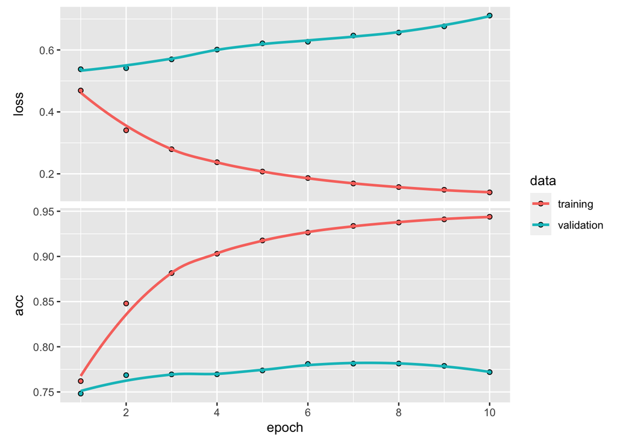

```r
history <- model5 %>% fit(
  x_train, y_train,
  validation_data = list(x_val, y_val),
  epochs = 10,
  batch_size =128,
  verbose = 0
  )

plot(history)
```

```r
print(paste0("peak accuracy of the model: ",max(history$metrics$val_acc)))
```

```
## [1] "peak accuracy of the model: 0.781433701515198"
```

```r
rm(model5)
set_random_seed(32)

model5 <- keras_model_sequential() %>%
  layer_embedding(input_dim = max_words, output_dim = 64,
                  input_length = maxlen) %>%
  layer_conv_1d(filters = 64, kernel_size = 7,
                activation = "relu") %>%
  layer_batch_normalization() %>%
  layer_conv_1d(filters = 64, kernel_size = 7,
                activation = "relu") %>%
  layer_global_max_pooling_1d() %>%
  layer_batch_normalization() %>%
  layer_dense(units = 1, activation = "sigmoid")


model5 %>% compile(
  optimizer = "adam",
  loss = "binary_crossentropy",
  metrics = c("acc")
)

model5 %>% fit(
  x_train, y_train,
  epochs = 7,
  batch_size = 128,
  verbose = 0
)
```

# Aggregating predictions

After fitting the different models on individual paragraphs from the corporate reports, we can now aggregate the models’ predictions to the level of the whole reports, to arrive at a single scandal prediction for each of the companies .

```r
aggregate_evaluate <- function(model){
  y_pred <- model %>%
    predict(x_val) %>% as.numeric()
  y_pred <- y_pred %>%
    as.data.frame() %>%
    cbind(raw_test$company.x,raw_test$year,raw_test$ntoken)
  colnames(y_pred) <- c("y_pred","company","year","ntoken")
  y_pred_firmyear <- y_pred %>%
    select(company,year,y_pred) %>%
    group_by(company,year) %>%
    summarise(scandal_prob = mean(y_pred))
  y_pred_firmyear$y_pred <- y_pred_firmyear$scandal_prob %>%
  `>`(0.5) %>% k_cast("int32") %>% as.numeric()
  y_test_firmyear <- raw_test %>%
    mutate(label = as.numeric(future_controversy)) %>%
    select(company.x,year,label) %>%
    group_by(company.x,year) %>%
    summarise(label_firmyear = mean(label))
  confusion_mat <- confusionMatrix(factor(y_pred_firmyear$y_pred),
                                   factor(y_test_firmyear$label_firmyear))
  print(confusion_mat)
}
```

##Model 1

```r
aggregate_evaluate(model1)
```

```
## Confusion Matrix and Statistics
##
##           Reference
## Prediction   0   1
##          0 120  15
##          1   7  70
##
##                Accuracy : 0.8962
##                  95% CI : (0.8471, 0.9338)
##     No Information Rate : 0.5991
##     P-Value [Acc > NIR] : <2e-16
##
##                   Kappa : 0.7806
##
##  Mcnemar's Test P-Value : 0.1356
##
##             Sensitivity : 0.9449
##             Specificity : 0.8235
##          Pos Pred Value : 0.8889
##          Neg Pred Value : 0.9091
##              Prevalence : 0.5991
##          Detection Rate : 0.5660
##    Detection Prevalence : 0.6368
##       Balanced Accuracy : 0.8842
##
##        'Positive' Class : 0
##
```

##Model 2

```r
aggregate_evaluate(model2)
```

```
## Confusion Matrix and Statistics
##
##           Reference
## Prediction   0   1
##          0 119  15
##          1   8  70
##
##                Accuracy : 0.8915
##                  95% CI : (0.8417, 0.93)
##     No Information Rate : 0.5991
##     P-Value [Acc > NIR] : <2e-16
##
##                   Kappa : 0.771
##
##  Mcnemar's Test P-Value : 0.2109
##
##             Sensitivity : 0.9370
##             Specificity : 0.8235
##          Pos Pred Value : 0.8881
##          Neg Pred Value : 0.8974
##              Prevalence : 0.5991
##          Detection Rate : 0.5613
##    Detection Prevalence : 0.6321
##       Balanced Accuracy : 0.8803
##
##        'Positive' Class : 0
##
```

##Model 3

```r
aggregate_evaluate(model3)
```

```
## Confusion Matrix and Statistics
##
##           Reference
## Prediction   0   1
##          0 119  15
##          1   8  70
##
##                Accuracy : 0.8915
##                  95% CI : (0.8417, 0.93)
##     No Information Rate : 0.5991
##     P-Value [Acc > NIR] : <2e-16
##
##                   Kappa : 0.771
##
##  Mcnemar's Test P-Value : 0.2109
##
##             Sensitivity : 0.9370
##             Specificity : 0.8235
##          Pos Pred Value : 0.8881
##          Neg Pred Value : 0.8974
##              Prevalence : 0.5991
##          Detection Rate : 0.5613
##    Detection Prevalence : 0.6321
##       Balanced Accuracy : 0.8803
##
##        'Positive' Class : 0
##
```

##Model 4

```r
aggregate_evaluate(model4)
```

```
## Confusion Matrix and Statistics
##
##           Reference
## Prediction   0   1
##          0 116  12
##          1  11  73
##
##                Accuracy : 0.8915
##                  95% CI : (0.8417, 0.93)
##     No Information Rate : 0.5991
##     P-Value [Acc > NIR] : <2e-16
##
##                   Kappa : 0.7737
##
##  Mcnemar's Test P-Value : 1
##
##             Sensitivity : 0.9134
##             Specificity : 0.8588
##          Pos Pred Value : 0.9062
##          Neg Pred Value : 0.8690
##              Prevalence : 0.5991
##          Detection Rate : 0.5472
##    Detection Prevalence : 0.6038
##       Balanced Accuracy : 0.8861
##
##        'Positive' Class : 0
##
```

##Model 5

```r
aggregate_evaluate(model5)
```

```
## Confusion Matrix and Statistics
##
##           Reference
## Prediction   0   1
##          0 119  15
##          1   8  70
##
##                Accuracy : 0.8915
##                  95% CI : (0.8417, 0.93)
##     No Information Rate : 0.5991
##     P-Value [Acc > NIR] : <2e-16
##
##                   Kappa : 0.771
##
##  Mcnemar's Test P-Value : 0.2109
##
##             Sensitivity : 0.9370
##             Specificity : 0.8235
##          Pos Pred Value : 0.8881
##          Neg Pred Value : 0.8974
##              Prevalence : 0.5991
##          Detection Rate : 0.5613
##    Detection Prevalence : 0.6321
##       Balanced Accuracy : 0.8803
##
##        'Positive' Class : 0
##
```